# Exploring the BRFSS data

## Setup

### Load packages

```r
library(ggplot2)
library(dplyr)
```

### Load data

```r
load("brfss2013.RData")
```

## Part 1: Data

The BRFSS has conducted monthly surveys since 1984 and these survey have been conducted using landline and cellular (since 2011). It is mentioned that landline surveys were randomly done, hence suggesting that there is possibility we can search for correlation between variables in data. This is not the case for cellular as the data obtained from cellular can tend to be biased (since it is not randomly asked rather asked to a specific group of people who reside in a private residence or college housing).

No random assignment exists in BRFSS scenario, suggesting that there would be no scope for causal relations. BRFSS dataset contains 330 variables and 491775 observations

## Part 2: Research questions

**Research quesion 1:** What state and gender has the highest depression? This relation is of interest as this information can be used to identify those states and gender with highest depression and address it accordingly.

The variables of interest are ‘addepev2’(Ever told you had a depressive disorder), ’_state’(the state they were from), and ‘sex’ (gender of the respondent).

**Research quesion 2:** For the year 2014 which state has the lowest average sleep time? This question is of interest as low sleep time can be a result of stress, health issues, etc

The variables of interest are ‘iyear’, ’_state’, and ‘sleptim1’.

**Research quesion 3:** Is there a relation between having blood cholesterol checked, ever told blood pressure high and being diagnosed with heart attack. We are interested in this analysis to see if respondents who did not have them checked were diagnosed with heart attack or not, if that is the case we want to have them checked more and prevent heart attack.

The variables of interest are ‘bphigh4’,‘toldhi2’, and ‘cvdinfr4’.

## Part 3: Exploratory data analysis

**Research quesion 1:** What state and gender has the highest depression? (top 7)

```r
brfssq1<- brfss2013 %>% group_by(X_state, addepev2,sex) %>% summarise(count = n()) %>% filter(addepev2 == "Yes", !is.na(addepev2), !is.na(sex)) %>% arrange(desc(count))

head(brfssq1,7)
```

```
## Source: local data frame [7 x 4]
## Groups: X_state, addepev2 [7]
##
##         X_state addepev2    sex count
##          <fctr>   <fctr> <fctr> <int>
## 1       Florida      Yes Female  4645
## 2        Kansas      Yes Female  3085
## 3 Massachusetts      Yes Female  2310
## 4      Nebraska      Yes Female  2149
## 5     Minnesota      Yes Female  1961
## 6          Utah      Yes Female  1956
## 7          Ohio      Yes Female  1869
```

The above code has grouped state, depressed or not and gender and have found the count in descending order. The top 7 states and gender where depression is highest.

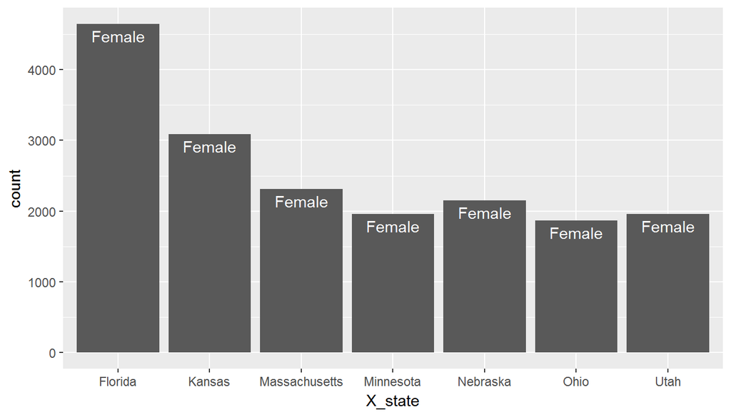

```r
ggplot(data = head(brfssq1,7), aes(x=X_state, y =count))+geom_bar(stat="identity")+geom_text(aes(label=sex),vjust=1.5, colour ="white")
```

As observed from the data, the top 7 states and genders are displayed and it is keen to note that it is females that are facing depression more in all these states.

**Research quesion 2:** For the year 2014 which state has the lowest average sleep time? (lowest 7)

```r
brfssq2 <- brfss2013 %>% group_by(X_state)%>%filter(!is.na(sleptim1),!is.na(X_state),iyear=="2014") %>% summarise(Average=mean(sleptim1)) %>% arrange(Average)

brfssq2
```

```
## # A tibble: 38 × 2
##      X_state  Average
##       <fctr>    <dbl>
## 1   Michigan 4.500000
## 2     Oregon 5.333333
## 3    Alabama 5.500000
## 4   Kentucky 6.000000
## 5   Arkansas 6.500000
## 6    Arizona 6.700000
## 7      Texas 6.700000
## 8       Guam 6.707317
## 9     Nevada 6.730769
## 10 Minnesota 6.800000
## # ... with 28 more rows
```

The above data represents the lowest average sleep time in each state for the year 2014. The output is arranged in ascending order (lease to highest) and saved into brfssq2

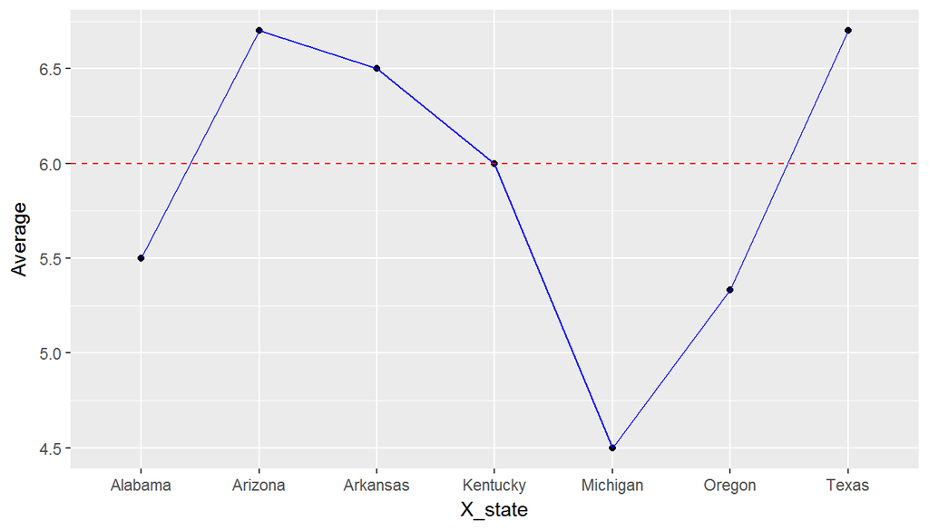

```r
ggplot(data = head(brfssq2,7),aes(x=X_state, y=Average, group= 1)) + geom_point() + geom_line(color = "blue") + geom_hline(yintercept = 6,linetype = "dashed", color="red")
```

Here we have considered a threshold average sleep time to be 6 hours and sleep time below that is considered very less and there would some health related problems existing or building up in those states.

**Research quesion 3:** Is there a relation between having blood cholesterol checked, ever told blood pressure high and being diagnosed with heart attack?

```r
brfssq3 <- brfss2013 %>% group_by(bphigh4,toldhi2, cvdinfr4) %>% summarise(count= n()) %>% filter(!is.na(bphigh4), !is.na(toldhi2), !is.na(cvdinfr4))

brfssq3
```

```
## Source: local data frame [16 x 4]
## Groups: bphigh4, toldhi2 [8]
##
##                                       bphigh4 toldhi2 cvdinfr4  count
##                                        <fctr>  <fctr>   <fctr>  <int>
## 1                                         Yes     Yes      Yes  15944
## 2                                         Yes     Yes       No  95250
## 3                                         Yes      No      Yes   5017
## 4                                         Yes      No       No  68463
## 5  Yes, but female told only during pregnancy     Yes      Yes     52
## 6  Yes, but female told only during pregnancy     Yes       No    760
## 7  Yes, but female told only during pregnancy      No      Yes     21
## 8  Yes, but female told only during pregnancy      No       No   1842
## 9                                          No     Yes      Yes   3422
## 10                                         No     Yes       No  64636
## 11                                         No      No      Yes   3160
## 12                                         No      No       No 154267
## 13        Told borderline or pre-hypertensive     Yes      Yes     98
## 14        Told borderline or pre-hypertensive     Yes       No   1850
## 15        Told borderline or pre-hypertensive      No      Yes     72
## 16        Told borderline or pre-hypertensive      No       No   2504
```

If we modify the code a bit to see which state has more number of people who have got heart attack when they had no blood pressure and no cholesterol level, we get the following code:

```r
brfssq3plot <- brfss2013 %>% group_by(X_state, bphigh4,toldhi2, cvdinfr4) %>% summarise(count= n()) %>% filter(!is.na(bphigh4), !is.na(toldhi2), !is.na(cvdinfr4), bphigh4=="No", toldhi2=="No", cvdinfr4=="Yes") %>% arrange(desc(count))
```

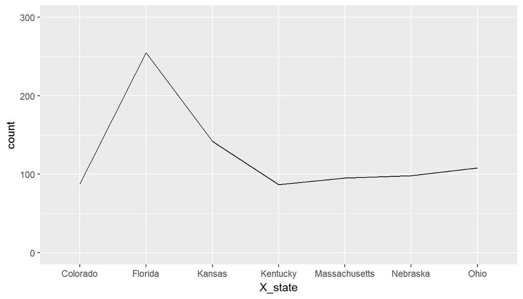

```r
ggplot(data=head(brfssq3plot,7), aes(x=X_state, y= count, group=1))+geom_line()+ylim(0,300)
```

The plot explains states(top 7) where people got a heart attack even though they were diagnosed with no blood pressure and no blood cholesterol.